# Self-Driving Car Engineer Nanodegree

## Project 3: Build a Traffic Sign Recognition Classifier

In this project we built a traffic sign classifier based on the German traffic sign dataset using a deep neural network trained in the tensorflow framework.

The goals / steps of this project are the following:

- Load the data set
- Explore, summarize and visualize the data set
- Design, train and test a model architecture
- Use the model to make predictions on new images
- Analyze the softmax probabilities of the new images
- Summarize the results with a written report

## Imports

```python
import numpy as np
import math
import pickle
import os
import sys

import matplotlib.pyplot as plt
import random
import csv

import cv2

import tensorflow as tf
from tensorflow.contrib.layers import flatten

SEED = 17
DATA_DIR='Data/'
OUT_DIR ='Out/'

# Set the seed, so we can replicate results
random.seed(SEED)
np.random.seed(SEED)
tf.set_random_seed(SEED)
```

## Load The Data

```python
DATA_PATH = 'Data/'

training_file = DATA_PATH + 'train.p'
validation_file= DATA_PATH + 'valid.p'
testing_file = DATA_PATH + 'test.p'

with open(training_file, mode='rb') as f:
    train = pickle.load(f)
with open(validation_file, mode='rb') as f:
    valid = pickle.load(f)
with open(testing_file, mode='rb') as f:
    test = pickle.load(f)

X_train, y_train = train['features'], train['labels']
X_valid, y_valid = valid['features'], valid['labels']
X_test, y_test = test['features'], test['labels']
```

## Dataset Summary & Exploration

The pickled data is a dictionary with 4 key/value pairs:

- `'features'` is a 4D array containing raw pixel data of the traffic sign images, (num examples, width, height, channels).
- `'labels'` is a 1D array containing the label/class id of the traffic sign. The file `signnames.csv` contains id -> name mappings for each id.
- `'sizes'` is a list containing tuples, (width, height) representing the original width and height the image.
- `'coords'` is a list containing tuples, (x1, y1, x2, y2) representing coordinates of a bounding box around the sign in the image. **THESE COORDINATES ASSUME THE ORIGINAL IMAGE. THE PICKLED DATA CONTAINS RESIZED VERSIONS (32 by 32) OF THESE IMAGES**

### Provide a Basic Summary of the Data Set Using Python, Numpy and/or Pandas

```python
# Number of training examples
n_train = len(X_train)

# Number of validation examples
n_validation = len(X_valid)

# Number of testing examples.
n_test = len(X_test)

# What's the shape of an traffic sign image?
image_shape = X_train[0].shape

# How many unique classes/labels there are in the dataset.
n_classes = len(np.unique(y_train))

print("Number of training examples =", n_train)
print("Number of validation examples =", n_validation)
print("Number of testing examples =", n_test)
print("Image data shape =", image_shape)
print("Number of classes =", n_classes)
```

```
Number of training examples = 34799
Number of validation examples = 4410
Number of testing examples = 12630
Image data shape = (32, 32, 3)
Number of classes = 43
```

### Include an exploratory visualization of the dataset

```python
def get_class_names(file_path):
    """
    Get class names of all the classes

    Parameters:
        - file_path: Path of the csv file

    Output:
        - array with the classnames
    """
    classnames = []
    with open(file_path) as _f:
        rows = csv.reader(_f, delimiter=',')
        # Skip headers
        next(rows, None)
        for i, row in enumerate(rows):
            assert(i == int(row[0]))
            # Append class name
            classnames.append(row[1])

    return classnames


def get_image_from_class(img_path, c):
    """
    Returns the image matching the corresponging class

    Parameters:
        - img_path: Path of the image that has all the signs
        - c: Class number

    Output:
        - image matching the given class
    """
    # Load the image in RGB
    img = cv2.imread(img_path)
    img = cv2.cvtColor(img, cv2.COLOR_BGR2RGB)

    # 7 images per row and 7 rows
    height, width, _ = img.shape
    dH = height / 7.
    dW = width / 7.104
    y = c // 7
    x = c % 7

    # Extract image
    label_image = img[round(y * dH) : round(y * dH + dH), round(x * dW) : round(x * dW + dW), :]
    label_image = cv2.resize(label_image, (0,0), fx = 32. / dW, fy = 32. / dH)
    return label_image


def insert_subimage(image, sub_image, y, x):
    """
    Inserts a subimage in a given image

    Parameters:
        - image: Parent image
        - sub_image: child image to be inserted
        - y: y position
        - x: x position

    Output:
        - image after insertion
    """
    height, width, c = sub_image.shape
    image[y : y + height, x : x + width, :] = sub_image
    return image


def create_image_of_dataset(img_path, train_images, labels, class_names, n_samples):
    """
    Returns the summary image of the dataset

    Parameters:
        - img_path: Path of the image that has all the signs
        - train_images: Images in the training dataset
        - labels: labels of the train_images
        - class_names: Array with the names of each class
        - n_samples: Number of samples to insert per class

    Output:
        - dataset_image: Contains the original class image, average class image,
                         sample images of that class and number of images
    """
    _, height, width, channel = train_images.shape
    n_classes = len(class_names)

    # Output image
    dataset_image = 255. * np.ones(shape =(n_classes * height,(n_samples + 24) * width, channel), dtype=np.float32)

    for c in range(n_classes):
        # Extract image of the class and insert it into dataset_image
        label_image = get_image_from_class(img_path, c)
        insert_subimage(dataset_image, label_image, c * height, 0)

        # Averaging image
        idx = list(np.where(labels == c)[0])
        mean_image = np.average(train_images[idx], axis = 0)
        insert_subimage(dataset_image, mean_image, c * height, width)

        # Random sampling
        for n in range(n_samples):
            sample_image = train_images[np.random.choice(idx)]
            insert_subimage(dataset_image, sample_image, c * height, (2 + n) * width)

        # Summary
        count = len(idx)
        color = [int(_) for _ in tuple(np.random.choice(range(255), size=3))]

        percentage = float(count) / float(len(train_images))
        cv2.putText(dataset_image,
                    ' {:02d}: {:6}'.format(c, class_names[c]),
                    ((2 + n_samples) * width, int((c + 0.7) * height)),
                    cv2.FONT_HERSHEY_SIMPLEX,0.5,(0,0,0),1,
                    cv2.LINE_AA)
        cv2.putText(dataset_image,
                    '{:4d}'.format(count),
                    ((2 + n_samples + 14) * width, int((c+0.7) * height)),
                    cv2.FONT_HERSHEY_SIMPLEX, 0.5, (0,0,255), 1)
        cv2.rectangle(dataset_image,
                      ((2 + n_samples + 16) * width, c * height),
                      ((2 + n_samples + 16) * width + round(percentage * 3000), (c+1)*height),
                      color,
                      -1)

        #cv2.imwrite(DATA_DIR+'/data_summary.jpg',cv2.cvtColor(results_image, cv2.COLOR_BGR2RGB))

    return dataset_image
```

[figure not shown]

```python
# Paths of image with all the signs and class names file
img_path = DATA_PATH +'/signnames_all.jpg'
class_names_path = DATA_PATH + 'signnames.csv'
# Sample images per class
n_samples = 10

# Build the final image
class_names = get_class_names(class_names_path)
dataset_image = create_image_of_dataset(img_path, X_train, y_train, class_names, n_samples)

plt.rcParams["figure.figsize"] = (25,25)
plt.imshow(dataset_image.astype(np.uint8))
plt.axis('off')
plt.show()
```

## Data Analysis

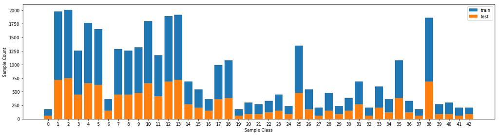

```
Minimum samples for any label in training data: 180
Maximum samples for any label in training data: 2010
Minimum samples for any label in test data: 60
Maximum samples for any label in test data: 750
```

```python
def get_data_stats(y_train, y_test):
    """
    Plots a graph and displays a summary of the training and test
    datasets.

    Parameters:
        - y_train: Labels related to the training dataset
        - y_test: Labels related to the test dataset
    """

    y_pos = range(n_classes)

    label_list = y_train.tolist()
    label_test_list = y_test.tolist()

    sign_type = ([label_list.count(n_class) for n_class in range(n_classes)])
    sign_test_type = ([label_test_list.count(n_class) for n_class in range(n_classes)])

    plt.figure(figsize=(20,5))
    plt.bar(y_pos, sign_type, tick_label = range(43), label = 'train')
    plt.bar(y_pos, sign_test_type, label = 'test')
    plt.ylabel('Sample Count')
    plt.xlabel('Sample Class')
    plt.legend(loc='upper right')
    plt.show()

    print("Minimum samples for any label in training data:", min(np.bincount(y_train)))
    print("Maximum samples for any label in training data:", max(np.bincount(y_train)))

    print("Minimum samples for any label in test data:", min(np.bincount(y_test)))
    print("Maximum samples for any label in test data:", max(np.bincount(y_test)))


get_data_stats(y_train, y_test)
```

## Pre-process the Data Set

Every batch will be normalized before feeding the network using a tensorflow batch normalization function, in this section we will cover how we extend the dataset to generate more data for the model. The functions are the following ones:

1. Extend data by flipping
2. Balance the data (all classes will have the same number of samples)
3. Perturb the image by warping and modifying brightness, contrast and saturation

```python
# Taken from http://navoshta.com/traffic-signs-classification/
def extend_data_by_flipping(images, labels, n_classes):
    """
    Extends the dataset by flipping it horizontally, vertically or both
    taking into account the relationships between the classes
    after the rotation.

    Parameters:
        - images: Images in the training dataset
        - labels: Labels of the training dataset
        - n_classes: Number of classes

    Output:
        - X_extended: Extended dataset of training images
        - y_extended: Extended dataset of training labels
    """

    X = images
    y = labels

    # Classes of signs that, when flipped horizontally, should still be classified as the same class
    self_flippable_horizontally = np.array([11, 12, 13, 15, 17, 18, 22, 26, 30, 35])
    # Classes of signs that, when flipped vertically, should still be classified as the same class
    self_flippable_vertically = np.array([1, 5, 12, 15, 17])
    # Classes of signs that, when flipped horizontally and then vertically, should still be classified as the same class
    self_flippable_both = np.array([32, 40])
    # Classes of signs that, when flipped horizontally, would still be meaningful, but should be classified as some other class
    cross_flippable = np.array([
        [19, 20],
        [33, 34],
        [36, 37],
        [38, 39],
        [20, 19],
        [34, 33],
        [37, 36],
        [39, 38],
    ])

    X_extended = np.empty([0, X.shape[1], X.shape[2], X.shape[3]], dtype = np.float32)
    y_extended = np.empty([0], dtype = np.int32)

    for c in range(n_classes):
        # First copy existing data for this class
        X_extended = np.append(X_extended, X[y == c], axis=0)
        # If we can flip images of this class horizontally and they would still belong to said class...
        if c in self_flippable_horizontally:
            # ...Copy their flipped versions into extended array.
            X_extended = np.append(X_extended, X[y == c][:, :, ::-1, :], axis=0)
        # If we can flip images of this class horizontally and they would belong to other class...
        if c in cross_flippable[:, 0]:
            # ...Copy flipped images of that other class to the extended array.
            flip_class = cross_flippable[cross_flippable[:, 0] == c][0][1]
            X_extended = np.append(X_extended, X[y == flip_class][:, :, ::-1, :], axis=0)
        # Fill labels for added images set to current class.
        y_extended = np.append(y_extended, np.full((X_extended.shape[0] - y_extended.shape[0]), c, dtype=np.int32))

        # If we can flip images of this class vertically and they would still belong to said class...
        if c in self_flippable_vertically:
            # ...Copy their flipped versions into extended array.
            X_extended = np.append(X_extended, X_extended[y_extended == c][:, ::-1, :, :], axis=0)
        # Fill labels for added images set to current class.
        y_extended = np.append(y_extended, np.full((X_extended.shape[0] - y_extended.shape[0]), c, dtype=np.int32))

        # If we can flip images of this class horizontally AND vertically and they would still belong to said class...
        if c in self_flippable_both:
            # ...Copy their flipped versions into extended array.
            X_extended = np.append(X_extended, X_extended[y_extended == c][:, ::-1, ::-1, :], axis=0)
        # Fill labels for added images set to current class.
        y_extended = np.append(y_extended, np.full((X_extended.shape[0] - y_extended.shape[0]), c, dtype=np.int32))

    return (X_extended, y_extended)


def perturb(image, keep, angle_limit=15, scale_limit=0.1, translate_limit=3, distort_limit=3, illumin_limit=0.7):
    """
    Perturb an image (warping, brightness, contrast and saturation)
    based on a given probability (keep) and uses random uniform
    distribution for perturbed values.

    Parameters:
        - image: Image to be perturbed
        - keep: Probability of the image to not be perturbed
        - angle_limit: Limit of the rotation angle for the image
        - scale_limit: Limit of the scale for the image
        - translate_limit: Limit of the translation for the image
        - distort_limit: Limit of the distortion noise to be added
        - illumin_limit: Limit of the illumination for the image

    Output:
        - image: Either perturbed or original image
                 depending on the keep probability
    """
    u = np.random.uniform()

    if u > keep :
        (width, height, channel) = image.shape
        center = np.array([width / 2., height / 2.])
        da = np.random.uniform(low=-1, high=1) * angle_limit/180. * math.pi
        scale = np.random.uniform(low=-1, high=1) * scale_limit + 1

        cc = scale * math.cos(da)
        ss = scale * math.sin(da)
        rotation    = np.array([[cc, ss], [-ss, cc]])
        translation = np.random.uniform(low=-1, high=1, size=(1,2)) * translate_limit
        distort     = np.random.standard_normal(size=(4,2)) * distort_limit

        # Warping points
        pts1 = np.array([[0., 0.], [0., width], [width, height], [width, 0.]])
        pts2 = np.matmul(pts1-center, rotation) + center  + translation

        # Add perspective noise
        pts2 = pts2 + distort

        # Distortion matrix and distorted image
        matrix  = cv2.getPerspectiveTransform(pts1.astype(np.float32), pts2.astype(np.float32))
        perturb = cv2.warpPerspective(image, matrix, (width, height), flags=cv2.INTER_LINEAR,
                                      borderMode=cv2.BORDER_REFLECT_101)  # BORDER_WRAP  #BORDER_REFLECT_101  #cv2.BORDER_CONSTANT  BORDER_REPLICATE

        # Brightness
        if 1:
            alpha = 1.0 + illumin_limit * random.uniform(-1, 1)
            perturb *= alpha
            perturb = np.clip(perturb, 0., 255.)
            pass

        # Contrast
        if 1:
            # RGB to gray (YCbCr) :  Y = 0.299R + 0.587G + 0.114B
            coef = np.array([[[0.299, 0.587, 0.114]]])

            alpha = 1.0 + illumin_limit * random.uniform(-1, 1)
            gray = perturb * coef
            gray = (3.0 * (1.0 - alpha) / gray.size) * np.sum(gray)
            perturb *= alpha
            perturb += gray
            perturb = np.clip(perturb,0.,255.)
            pass

        # Saturation
        if 1:
            coef = np.array([[[0.299, 0.587, 0.114]]])

            alpha = 1.0 + illumin_limit*random.uniform(-1, 1)
            gray = perturb * coef
            gray = np.sum(gray, axis=2, keepdims=True)
            gray *= (1.0 - alpha)
            perturb *= alpha
            perturb += gray
            perturb = np.clip(perturb,0.,255.)
            pass

        return perturb

    else:
        return image


def make_perturb_images(images, keep):
    """
    Perturb the given images

    Parameters:
        - images: Images to be perturbed
        - keep: Probability of the image to not be perturbed

    Output:
        - Perturbed images
    """
    perturbed_images = np.zeros(images.shape)
    for n in range(len(images)):
        perturbed_images[n] = perturb(images[n],keep = keep)

    return perturbed_images


def balance_data(images, labels, n_classes, num_per_class=None):
    """
    Balance and shuffle the data (i.e. same
    number of samples in each class).

    Parameters:
        - images: Images in the training dataset
        - labels: Labels in the training dataset
        - n_classes: Total number of classes
        - num_per_class: Desired number of images per class

    Output:
        - shuffle_images: Balanced and shuffled images
        - shuffle_labels: Balanced and shuffled labels
    """
    # Get maximum number of images in a class
    if num_per_class is None:
        max_count = 0
        for c in range(n_classes):
            idx = list(np.where(labels == c)[0])
            count = len(idx)
            max_count = max(count, max_count)
        num_per_class = max_count

    index = []
    for c in range(n_classes):
        idx = list(np.where(labels == c)[0])
        index = index + list(np.random.choice(idx, num_per_class))

    random.shuffle(index)
    shuffle_images  = images[index]
    shuffle_labels = labels[index]

    return shuffle_images, shuffle_labels
```

```
Number of training images after flipping: 59788
Total of images after balancing: 86000
```

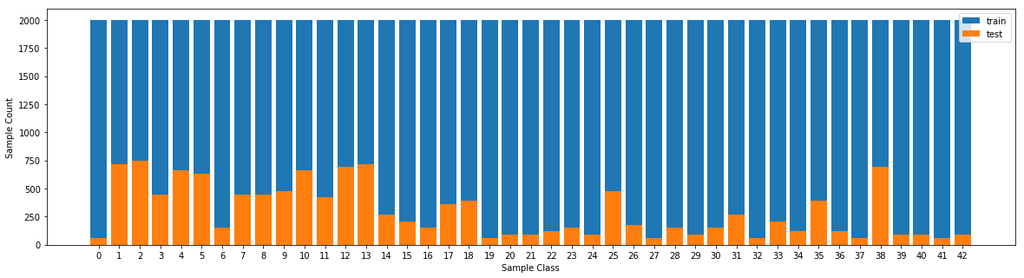

```
Minimum samples for any label in training data: 2000
Maximum samples for any label in training data: 2000
Minimum samples for any label in test data: 60
Maximum samples for any label in test data: 750
```

```python
# Train data filpping.
train_images, train_labels = extend_data_by_flipping(X_train, y_train, n_classes)
num_train_flip = len(train_images)
print('Number of training images after flipping: {:d}'.format(num_train_flip))

# Keep 20 percent of the data
keep = 0.20
# Balance to 2000 images per class
num_per_class = 2000
# Total of images in train set
total_images = num_per_class * n_classes

# Balance the data
train_balanced_images, train_balanced_labels = balance_data(train_images,
                                                            train_labels,
                                                            n_classes,
                                                            num_per_class = num_per_class)
# Perturb 80% of images, 100-20 = 80
train_balanced_images = make_perturb_images(train_balanced_images, keep = keep)
print('Total of images after balancing: {:d}'.format(total_images))

# Display graph of data balanced
get_data_stats(train_balanced_labels, y_test)
```

## Step 2: Design and Test a Model Architecture

Design and implement a deep learning model that learns to recognize traffic signs. Train and test your model on the [German Traffic Sign Dataset](http://benchmark.ini.rub.de/?section=gtsrb&subsection=dataset).

There are various aspects to consider when thinking about this problem:

- Neural network architecture (is the network over or underfitting?)
- Play around preprocessing techniques (normalization, rgb to grayscale, etc)
- Number of examples per label (some have more than others).
- Generate fake data.

### Model Architecture

```python
#Modified LeNet Architecture

# conv1->relu->pool->dropout->conv2->relu->pool->dropout->conv3->relu->pool->dropout->fc1->rel->dropout->fc2

conv1_W = None;
conv2_W = None;
conv3_W = None
fc1_W = None;
fc2_W = None;

def LeNet(x):
    """
    Creates every layer of the architecture of the neural network,
    this project consists of 3 convolutional layers and 2 dense
    layers.

    Parameters:
        - images: Images in the training dataset

    Output:
        - Logits of the neural network
    """

    global conv1_W,conv2_W, conv3_W, fc1_W, fc2_W
    # Arguments used for tf.truncated_normal, randomly defines variables for the weights and biases for each layer
    mu = 0
    sigma = 0.1

    # SOLUTION: Normalize dataset before feeding the network
    input = tf.contrib.layers.batch_norm(x, decay = 0.9, epsilon = 1e-5, center = True, scale = True,
                              is_training = 1,reuse = None, updates_collections = None)


    # SOLUTION: Layer 1: Convolutional. Input = 32x32x3. Output = 32x32x16.
    conv1_W = tf.Variable(tf.truncated_normal(shape=(5, 5, 3, 16), mean = mu, stddev = sigma))
    conv1_b = tf.Variable(tf.zeros(16))
    conv1   = tf.nn.conv2d(input, conv1_W, strides=[1, 1, 1, 1], padding='SAME') + conv1_b
    print ('conv1-->', conv1)
    tf.add_to_collection('vars', conv1_W)

    # SOLUTION: Activation.
    conv1 = tf.nn.relu(conv1)
    print ('conv1 activation-->', conv1)
    # SOLUTION: Pooling. Input = 32x32x16. Output = 16x16x16.
    conv1 = tf.nn.max_pool(conv1, ksize=[1, 2, 2, 1], strides=[1, 2, 2, 1], padding='SAME')
    print ('conv1 pooling -->', conv1)

    # Dropout
    conv1 = tf.nn.dropout(conv1, keep_prob_conv1)
    print ('conv1 dropout -->', conv1)



    # SOLUTION: Layer 2: Convolutional. Input = 16x16x16 Output = 16x16x32?
    conv2_W = tf.Variable(tf.truncated_normal(shape=(5, 5, 16, 32), mean = mu, stddev = sigma))
    conv2_b = tf.Variable(tf.zeros(32))
    conv2   = tf.nn.conv2d(conv1, conv2_W, strides=[1, 1, 1, 1], padding='SAME') + conv2_b
    print ('conv2-->', conv2)
    tf.add_to_collection('vars', conv2_W)

    # SOLUTION: Activation.
    conv2 = tf.nn.relu(conv2)
    print ('conv2 activation-->', conv2)

    # SOLUTION: Pooling. Input = 16x16x32. Output = 8x8x32.
    conv2 = tf.nn.max_pool(conv2, ksize=[1, 2, 2, 1], strides=[1, 2, 2, 1], padding='SAME')
    print ('conv2 pooling-->', conv2)

    # Dropout
    conv2 = tf.nn.dropout(conv2, keep_prob_conv2)
    print ('conv2 dropout-->', conv2)



    # SOLUTION: Layer 3: Convolutional. Input =8x8x32 Output = 8x8x64?
    conv3_W = tf.Variable(tf.truncated_normal(shape=(5, 5, 32, 64), mean = mu, stddev = sigma))
    conv3_b = tf.Variable(tf.zeros(64))
    conv3   = tf.nn.conv2d(conv2, conv3_W, strides=[1, 1, 1, 1], padding='SAME') + conv3_b
    print ('conv3-->', conv3)
    tf.add_to_collection('vars', conv3_W)

    # SOLUTION: Activation.
    conv3 = tf.nn.relu(conv3)
    print ('conv3 activation-->', conv3)

    # SOLUTION: Pooling. Input = 8x8x64. Output = 4x4x64.
    conv3 = tf.nn.max_pool(conv3, ksize=[1, 2, 2, 1], strides=[1, 2, 2, 1], padding='SAME')
    print ('conv3 pooling-->', conv3)

    # Dropout
    conv3 = tf.nn.dropout(conv3, keep_prob_conv3)
    print ('conv3 pooling-->', conv3)



    # SOLUTION: Flatten. Input = 4x4x64. Output = 1024.
    fc0   = flatten(conv3)
    print ('flattened layer shape-->', fc0)

    # SOLUTION: Layer 3: Fully Connected. Input = 1024. Output = 84.
    fc1_W = tf.Variable(tf.truncated_normal(shape=(1024, 84), mean = mu, stddev = sigma))
    fc1_b = tf.Variable(tf.zeros(84))
    fc1   = tf.matmul(fc0, fc1_W) + fc1_b
    print ('fc1 shape-->', fc1)
    tf.add_to_collection('vars', fc1_W)

    # SOLUTION: Activation.
    fc1    = tf.nn.relu(fc1)
    print ('fc1 activation-->', fc1)

    #dropout
    fc1 = tf.nn.dropout(fc1, keep_prob_fc1)
    print ('fc1 dropout-->', fc1)



    # SOLUTION: Layer 5: Fully Connected. Input = 84. Output = 43.
    fc2_W  = tf.Variable(tf.truncated_normal(shape=(84, 43), mean = mu, stddev = sigma))
    fc2_b  = tf.Variable(tf.zeros(43))
    logits = tf.matmul(fc1, fc2_W) + fc2_b
    print ('logits-->', logits)
    tf.add_to_collection('vars', fc2_W)
    tf.add_to_collection('vars', logits)

    return logits
```

### Train, Validate and Test the Model

A validation set can be used to assess how well the model is performing. A low accuracy on the training and validation sets imply underfitting. A high accuracy on the training set but low accuracy on the validation set implies overfitting.

```python
### Train your model here.
### Calculate and report the accuracy on the training and validation set.
### Once a final model architecture is selected,
### the accuracy on the test set should be calculated and reported as well.
### Feel free to use as many code cells as needed.
from sklearn.utils import shuffle
import matplotlib.pyplot as plt

# Training images and labels placeholders
x = tf.placeholder(tf.float32, (None, 32, 32, 3))
y = tf.placeholder(tf.int32, (None))
one_hot_y = tf.one_hot(y, 43)

# Probabilities to keep neurons in each layer
keep_prob_conv1 = tf.placeholder(tf.float32)
keep_prob_conv2 = tf.placeholder(tf.float32)
keep_prob_conv3 = tf.placeholder(tf.float32)
keep_prob_fc1 = tf.placeholder(tf.float32)

# Learning rate
rate = 0.0005

print('Summary CNN model\n')
print('----------------------------------------------------------------------------------------------')

# Logits
logits = LeNet(x)

# Neural network operations
# Using L2 regularizers
regularizers = tf.nn.l2_loss(conv1_W) + tf.nn.l2_loss(conv2_W) + tf.nn.l2_loss(conv3_W) + tf.nn.l2_loss(fc1_W) + tf.nn.l2_loss(fc2_W)
cross_entropy = tf.nn.softmax_cross_entropy_with_logits(labels=one_hot_y, logits=logits)
loss_operation = tf.reduce_mean(cross_entropy + 0.00005 * regularizers)
optimizer = tf.train.AdamOptimizer(learning_rate = rate)
training_operation = optimizer.minimize(loss_operation)

# Predictions
correct_prediction = tf.equal(tf.argmax(logits, 1), tf.argmax(one_hot_y, 1))
accuracy_operation = tf.reduce_mean(tf.cast(correct_prediction, tf.float32))
saver = tf.train.Saver()
```

```
Summary CNN model

----------------------------------------------------------------------------------------------
conv1--> Tensor("add:0", shape=(?, 32, 32, 16), dtype=float32)
conv1 activation--> Tensor("Relu:0", shape=(?, 32, 32, 16), dtype=float32)
conv1 pooling --> Tensor("MaxPool:0", shape=(?, 16, 16, 16), dtype=float32)
conv1 dropout --> Tensor("dropout/mul:0", shape=(?, 16, 16, 16), dtype=float32)
conv2--> Tensor("add_1:0", shape=(?, 16, 16, 32), dtype=float32)
conv2 activation--> Tensor("Relu_1:0", shape=(?, 16, 16, 32), dtype=float32)
conv2 pooling--> Tensor("MaxPool_1:0", shape=(?, 8, 8, 32), dtype=float32)
conv2 dropout--> Tensor("dropout_1/mul:0", shape=(?, 8, 8, 32), dtype=float32)
conv3--> Tensor("add_2:0", shape=(?, 8, 8, 64), dtype=float32)
conv3 activation--> Tensor("Relu_2:0", shape=(?, 8, 8, 64), dtype=float32)
conv3 pooling--> Tensor("MaxPool_2:0", shape=(?, 4, 4, 64), dtype=float32)
conv3 pooling--> Tensor("dropout_2/mul:0", shape=(?, 4, 4, 64), dtype=float32)
flattened layer shape--> Tensor("Flatten/Reshape:0", shape=(?, 1024), dtype=float32)
fc1 shape--> Tensor("add_3:0", shape=(?, 84), dtype=float32)
fc1 activation--> Tensor("Relu_3:0", shape=(?, 84), dtype=float32)
fc1 dropout--> Tensor("dropout_3/mul:0", shape=(?, 84), dtype=float32)
logits--> Tensor("add_4:0", shape=(?, 43), dtype=float32)
```

```python
def evaluate(X_data, y_data, batch_size):
    """
    Model accuracy evaluation function.

    Parameters:
        - X_data: Images
        - y_data: Labels
        - batch_size: Number of images per batch

    Output:
        - accuracy of the model
    """
    num_training = len(X_data)
    total_accuracy = 0

    sess = tf.get_default_session()
    for offset in range(0, num_training, batch_size):
        batch_x, batch_y = X_data[offset:offset + batch_size], y_data[offset:offset + batch_size]
        # Evaluate the accuracy, remove dropouts, we want to use all neurons for evaluation
        accuracy = sess.run(accuracy_operation, feed_dict={x: batch_x,
                                                           y: batch_y,
                                                           keep_prob_conv1: 1.0,
                                                           keep_prob_conv2: 1.0,
                                                           keep_prob_conv3: 1.0,
                                                           keep_prob_fc1: 1.0})
        total_accuracy += (accuracy * len(batch_x))
    return total_accuracy / num_training


def plot_graph(epochs, accuracy, rate, batch_size, arch_name):
    """
    Displays and saves the graph of the model, epochs vs accuracy

    Parameters:
        - epochs: Number of epochs
        - accuracy: Accuracy array
        - rate: Learning rate
        - batch_size: Number of images per batch
        - arch_name: Name of the architecture
    """
    fig1 = plt.figure(figsize=(10,6))
    plt.plot(epochs, accuracy)
    plt.xlim(0, len(epochs))
    plt.ylim(0, 1)
    plt.xlabel('epochs')
    plt.ylabel('validation - accuracy')
    plt.title(arch_name + '--> Validation Accuracy - Epoch')
    fig1.savefig('results/' + arch_name + "__" + str(rate) + "_" + str(batch_size) + ".jpeg", bbox_inches='tight')
```

```
Training model with 86000 images


 epoch   iter    |  batch_acc   |  valid_acc
------------------------------------------------
  1.0   000672   |  0.035714    |  0.072562
  2.0   001344   |  0.125000    |  0.134014
  3.0   002016   |  0.151786    |  0.217007
  4.0   002688   |  0.214286    |  0.321995
  5.0   003360   |  0.285714    |  0.348073
  6.0   004032   |  0.321429    |  0.375510
  7.0   004704   |  0.401786    |  0.437188
  8.0   005376   |  0.526786    |  0.502494
  9.0   006048   |  0.598214    |  0.551020
 10.0   006720   |  0.642857    |  0.597279
 11.0   007392   |  0.732143    |  0.673243
 12.0   008064   |  0.723214    |  0.699546
 13.0   008736   |  0.803571    |  0.735374
 14.0   009408   |  0.839286    |  0.748980
 15.0   010080   |  0.812500    |  0.755329
 16.0   010752   |  0.848214    |  0.784127
 17.0   011424   |  0.848214    |  0.795465
 18.0   012096   |  0.875000    |  0.806576
 19.0   012768   |  0.883929    |  0.821995
 20.0   013440   |  0.883929    |  0.838776
 21.0   014112   |  0.901786    |  0.843311
 22.0   014784   |  0.892857    |  0.862358
 23.0   015456   |  0.901786    |  0.858730
 24.0   016128   |  0.937500    |  0.882313
 25.0   016800   |  0.937500    |  0.869841
 26.0   017472   |  0.928571    |  0.879365
 27.0   018144   |  0.937500    |  0.885941
 28.0   018816   |  0.946429    |  0.897959
 29.0   019488   |  0.955357    |  0.899773
 30.0   020160   |  0.964286    |  0.908163
 31.0   020832   |  0.973214    |  0.908390
 32.0   021504   |  0.955357    |  0.914512
 33.0   022176   |  0.955357    |  0.919955
 34.0   022848   |  0.973214    |  0.909977
 35.0   023520   |  0.973214    |  0.925850
```

[output cut: 151 more lines]

```
187.0   125664   |  0.973214    |  0.978231
188.0   126336   |  0.982143    |  0.978685
189.0   127008   |  0.982143    |  0.979138
190.0   127680   |  0.991071    |  0.979365
191.0   128352   |  0.982143    |  0.981633
192.0   129024   |  0.991071    |  0.975737
193.0   129696   |  0.982143    |  0.975737
194.0   130368   |  0.991071    |  0.977098
195.0   131040   |  0.991071    |  0.978005
196.0   131712   |  0.982143    |  0.977098
197.0   132384   |  0.991071    |  0.973469
198.0   133056   |  0.982143    |  0.974603
199.0   133728   |  0.982143    |  0.978458
200.0   134400   |  0.982143    |  0.977778
Model saved
```

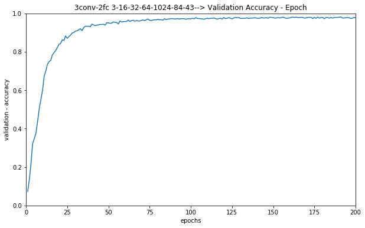

```python
# Control variables
EPOCHS = 200
BATCH_SIZE = 128
ARCH_NAME = '3conv-2fc 3-16-32-64-1024-84-43'

# Train the model
with tf.Session() as sess:
    sess.run(tf.global_variables_initializer())

    # Array to store the accuracy of the validation set
    # at each epoch
    validation_acc = []
    # Current batch accuracy
    batch_acc = None

    num_training = len(train_balanced_images)

    print("Training model with", num_training, "images\n\n")
    print(' epoch   iter    |  batch_acc   |  valid_acc    ')
    print('------------------------------------------------')

    # Variable to store the current iteration
    iteration = 0

    for epoch in range(EPOCHS):
        for offset in range(0, num_training, BATCH_SIZE):
            iteration += 1
            fraction_epoch = float(iteration * BATCH_SIZE) / float(num_training)

            # Creating mini-batch set
            end = offset + BATCH_SIZE
            batch_x, batch_y = train_balanced_images[offset:end], train_balanced_labels[offset:end]

            # Run the training phase in the mini-batch
            sess.run(training_operation, feed_dict={x: batch_x,
                                                    y: batch_y,
                                                    keep_prob_conv1: 0.9,
                                                    keep_prob_conv2: 0.6,
                                                    keep_prob_conv3: 0.6,
                                                    keep_prob_fc1: 0.5})

            # Evaluate accuracy in the current batch
            batch_acc = evaluate(batch_x, batch_y, BATCH_SIZE)
            print('\r{:5.1f}   {:06d}   |  {:f}    |'.format(fraction_epoch,
                                                                  iteration,
                                                                  batch_acc), end = '', flush = True)

        # Evaluate accuracy in the validation set after the epoch finalization
        validation_acc.append(evaluate(X_valid, y_valid, BATCH_SIZE))
        print('\r{:5.1f}   {:06d}   |  {:f}    |  {:f}  '.format(fraction_epoch,
                                                                 iteration,
                                                                 batch_acc,
                                                                 validation_acc[epoch]), end = '\n', flush = True)
    # Save the model and display the graph
    saver.save(sess, 'Model/{}'.format(ARCH_NAME))
    print("Model saved")
    plot_graph(list(np.arange(1,(EPOCHS+1))), validation_acc, rate, BATCH_SIZE, ARCH_NAME)
```

### Accuracy of training, validation and test datasets

```python
with tf.Session() as sess:
    saver.restore(sess, 'Model/3conv-2fc 3-16-32-64-1024-84-43')#tf.train.latest_checkpoint('.'))
    print('  Dataset    |   Accuracy  ')
    print('---------------------------')

    # Evaluate datasets
    training_accuracy = evaluate(train_balanced_images, train_balanced_labels, BATCH_SIZE)
    validation_accuracy = evaluate(X_valid, y_valid, BATCH_SIZE)
    test_accuracy = evaluate(X_test, y_test, BATCH_SIZE)

    # Print results
    print('  Training   |  {:f}  '.format(training_accuracy))
    print('  Validation |  {:f}  '.format(validation_accuracy))
    print('  Test       |  {:f}  '.format(test_accuracy))

    # Saving results
    with open('results/result.txt', 'a') as f:
        f.write("""
        Architecture: {}, Epochs {:d}, Batch size: {:d}
        -----------------------------------------------------------------------------
        Training   Accuracy:   {:f}
        Validation Accuracy:   {:f}
        Test       Accuracy:    {:f}
        \n
        """.format(ARCH_NAME,
                   EPOCHS,
                   BATCH_SIZE,
                   training_accuracy,
                   validation_accuracy,
                   test_accuracy))



# Restore the model if session was shutdown
#with tf.Session() as sess:
    #sess.run(tf.global_variables_initializer())
    #saver = tf.train.import_meta_graph('Model/3conv-2fc 3-16-32-64-1024-84-43.meta')
    #saver.restore(sess, "Model/3conv-2fc 3-16-32-64-1024-84-43")
    #print("Lenet Model restored...")
    #Train_accuracy = evaluate(X_train, y_train)
    #print("Train Accuracy = {:.3f}".format(Train_accuracy))
```

```
INFO:tensorflow:Restoring parameters from Model/3conv-2fc 3-16-32-64-1024-84-43
  Dataset    |   Accuracy
---------------------------
  Training   |  0.984767
  Validation |  0.977778
  Test       |  0.971971
```

## Step 3: Test a Model on New Images

### Load and Output the Images

```
image file stop.jpg  image shape-> (864, 1152, 3)
image file stop.jpg  image shape-> (32, 32, 3)

image file caution.jpg  image shape-> (32, 32, 3)
image file caution.jpg  image shape-> (32, 32, 3)

image file turn-left-ahead.jpg  image shape-> (32, 32, 3)
image file turn-left-ahead.jpg  image shape-> (32, 32, 3)

image file thirty-speed-limit.jpg  image shape-> (32, 32, 3)
image file thirty-speed-limit.jpg  image shape-> (32, 32, 3)

image file fifty-speed-limit.jpg  image shape-> (318, 310, 3)
image file fifty-speed-limit.jpg  image shape-> (32, 32, 3)
```

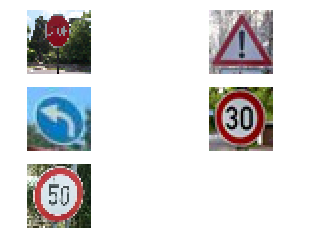

```python
### Load the images and plot them here.
### Feel free to use as many code cells as needed.
%matplotlib inline
import matplotlib.pyplot as plt
import matplotlib.image as mpimg
import matplotlib
import numpy as np
import cv2
import os

# Path of the new images
additional_data_dir = 'New_Data/'

# Load the images into array
additional_images = []
for filename in os.listdir(additional_data_dir):
    if filename == '.DS_Store':
        continue
    if not os.path.isdir(filename):
        image = mpimg.imread(os.path.join(additional_data_dir, filename))
        print('image file', filename, ' image shape->', image.shape)
        image = cv2.resize(image, (32, 32))
        print('image file', filename, ' image shape->', image.shape, '\n')
        additional_images.append(np.array(image))
additional_images = np.asarray(additional_images)

# Create the labels of the images
labels_additional_images = [14, 18, 34, 1, 2]
labels_additional_images = np.asarray(labels_additional_images)

# Display images
fig, axs = plt.subplots(3, 2)
for i, ax in enumerate(axs.flat):
    ax.axis('off')
    if i < 5:
        ax.imshow(additional_images[i])
```

### Predict the Sign Type for Each Image

```python
### Run the predictions here and use the model to output the prediction for each image.
### Make sure to pre-process the images with the same pre-processing pipeline used earlier.
### Feel free to use as many code cells as needed.
with tf.Session() as sess:
    saver.restore(sess, 'Model/3conv-2fc 3-16-32-64-1024-84-43')
    prediction = tf.argmax(logits, 1)
    results = sess.run(prediction, feed_dict={x: additional_images,
                                              y: labels_additional_images,
                                              keep_prob_conv1: 1.0,
                                              keep_prob_conv2: 1.0,
                                              keep_prob_conv3: 1.0,
                                              keep_prob_fc1: 1.0})
    for i,result in enumerate(results):
        print('Predicted: {:02d} -> Label: {:02d} {}'.format(result,
                                                             labels_additional_images[i],
                                                             class_names[result]))
```

```
INFO:tensorflow:Restoring parameters from Model/3conv-2fc 3-16-32-64-1024-84-43
Predicted: 17 -> Label: 14 No entry
Predicted: 18 -> Label: 18 General caution
Predicted: 34 -> Label: 34 Turn left ahead
Predicted: 01 -> Label: 01 Speed limit (30km/h)
Predicted: 02 -> Label: 02 Speed limit (50km/h)
```

### Analyze Performance

```python
### Calculate the accuracy for these 5 new images.
### For example, if the model predicted 1 out of 5 signs correctly, it's 20% accurate on these new images.

with tf.Session() as sess:
    saver.restore(sess, 'Model/3conv-2fc 3-16-32-64-1024-84-43')
    # Calculate accuracy
    new_data_accuracy = evaluate(additional_images, labels_additional_images, BATCH_SIZE)
    print("Additional Image Test Accuracy: {:f}".format(new_data_accuracy))
```

```
INFO:tensorflow:Restoring parameters from Model/3conv-2fc 3-16-32-64-1024-84-43
Additional Image Test Accuracy: 0.800000
```

### Output Top 5 Softmax Probabilities For Each Image Found on the Web

For each of the new images, print out the model's softmax probabilities to show the **certainty** of the model's predictions (limit the output to the top 5 probabilities for each image). [`tf.nn.top_k`](https://www.tensorflow.org/versions/r0.12/api_docs/python/nn.html#top_k) could prove helpful here.

The example below demonstrates how tf.nn.top_k can be used to find the top k predictions for each image.

`tf.nn.top_k` will return the values and indices (class ids) of the top k predictions. So if k=3, for each sign, it'll return the 3 largest probabilities (out of a possible 43) and the correspoding class ids.

Take this numpy array as an example. The values in the array represent predictions. The array contains softmax probabilities for five candidate images with six possible classes. `tf.nn.top_k` is used to choose the three classes with the highest probability:

```
# (5, 6) array
a = np.array([[ 0.24879643,  0.07032244,  0.12641572,  0.34763842,  0.07893497,
         0.12789202],
       [ 0.28086119,  0.27569815,  0.08594638,  0.0178669 ,  0.18063401,
         0.15899337],
       [ 0.26076848,  0.23664738,  0.08020603,  0.07001922,  0.1134371 ,
         0.23892179],
       [ 0.11943333,  0.29198961,  0.02605103,  0.26234032,  0.1351348 ,
         0.16505091],
       [ 0.09561176,  0.34396535,  0.0643941 ,  0.16240774,  0.24206137,
         0.09155967]])
```

Running it through `sess.run(tf.nn.top_k(tf.constant(a), k=3))` produces:

```
TopKV2(values=array([[ 0.34763842,  0.24879643,  0.12789202],
       [ 0.28086119,  0.27569815,  0.18063401],
       [ 0.26076848,  0.23892179,  0.23664738],
       [ 0.29198961,  0.26234032,  0.16505091],
       [ 0.34396535,  0.24206137,  0.16240774]]), indices=array([[3, 0, 5],
       [0, 1, 4],
       [0, 5, 1],
       [1, 3, 5],
       [1, 4, 3]], dtype=int32))
```

Looking just at the first row we get `[ 0.34763842, 0.24879643, 0.12789202]`, you can confirm these are the 3 largest probabilities in `a`. You'll also notice `[3, 0, 5]` are the corresponding indices.

```python
### Print out the top five softmax probabilities for the predictions on the German traffic sign images found on the web.
### Feel free to use as many code cells as needed.
softmax = tf.nn.softmax(logits)
with tf.Session() as sess:
    saver.restore(sess, 'Model/3conv-2fc 3-16-32-64-1024-84-43')
    # Calculate softmax probabilities
    probabilities = sess.run(softmax, feed_dict={x: additional_images,
                                                 y: labels_additional_images,
                                                 keep_prob_conv1: 1.0,
                                                 keep_prob_conv2: 1.0,
                                                 keep_prob_conv3: 1.0,
                                                 keep_prob_fc1: 1.0})
    # Get top five results
    probs, results = sess.run(tf.nn.top_k(probabilities, k = 5))

    # Print them
    for i, predictions in enumerate(results):
        print('Class {} - {}'.format(labels_additional_images[i],
                                     class_names[labels_additional_images[i]]))
        print('------------------------------------------------------------------')

        for rank, prediction in enumerate(predictions):
            print('Rank {}: {:2d} - {:1.5f} {}'.format(rank,
                                                    prediction,
                                                    probs[i][rank],
                                                    class_names[prediction]))

        print('')
```

```
INFO:tensorflow:Restoring parameters from Model/3conv-2fc 3-16-32-64-1024-84-43
Class 14 - Stop
------------------------------------------------------------------
Rank 0: 17 - 0.96401 No entry
Rank 1: 14 - 0.03594 Stop
Rank 2: 12 - 0.00002 Priority road
Rank 3: 10 - 0.00002 No passing for vehicles over 3.5 metric tons
Rank 4: 11 - 0.00000 Right-of-way at the next intersection

Class 18 - General caution
------------------------------------------------------------------
Rank 0: 18 - 1.00000 General caution
Rank 1: 27 - 0.00000 Pedestrians
Rank 2: 26 - 0.00000 Traffic signals
Rank 3: 11 - 0.00000 Right-of-way at the next intersection
Rank 4: 24 - 0.00000 Road narrows on the right

Class 34 - Turn left ahead
------------------------------------------------------------------
Rank 0: 34 - 1.00000 Turn left ahead
Rank 1: 38 - 0.00000 Keep right
Rank 2: 40 - 0.00000 Roundabout mandatory
Rank 3: 35 - 0.00000 Ahead only
Rank 4: 37 - 0.00000 Go straight or left

Class 1 - Speed limit (30km/h)
------------------------------------------------------------------
Rank 0:  1 - 1.00000 Speed limit (30km/h)
Rank 1:  2 - 0.00000 Speed limit (50km/h)
Rank 2:  0 - 0.00000 Speed limit (20km/h)
Rank 3:  5 - 0.00000 Speed limit (80km/h)
Rank 4:  4 - 0.00000 Speed limit (70km/h)

Class 2 - Speed limit (50km/h)
------------------------------------------------------------------
Rank 0:  2 - 0.98062 Speed limit (50km/h)
Rank 1:  5 - 0.01455 Speed limit (80km/h)
Rank 2:  1 - 0.00340 Speed limit (30km/h)
Rank 3:  7 - 0.00081 Speed limit (100km/h)
Rank 4:  3 - 0.00035 Speed limit (60km/h)
```

## Step 4 (Optional): Visualize the Neural Network's State with Test Images

This Section is not required to complete but acts as an additional excersise for understaning the output of a neural network's weights. While neural networks can be a great learning device they are often referred to as a black box. We can understand what the weights of a neural network look like better by plotting their feature maps. After successfully training your neural network you can see what it's feature maps look like by plotting the output of the network's weight layers in response to a test stimuli image. From these plotted feature maps, it's possible to see what characteristics of an image the network finds interesting. For a sign, maybe the inner network feature maps react with high activation to the sign's boundary outline or to the contrast in the sign's painted symbol.

Provided for you below is the function code that allows you to get the visualization output of any tensorflow weight layer you want. The inputs to the function should be a stimuli image, one used during training or a new one you provided, and then the tensorflow variable name that represents the layer's state during the training process, for instance if you wanted to see what the LeNet lab's feature maps looked like for it's second convolutional layer you could enter conv2 as the tf_activation variable.

For an example of what feature map outputs look like, check out NVIDIA's results in their paper [End-to-End Deep Learning for Self-Driving Cars](https://devblogs.nvidia.com/parallelforall/deep-learning-self-driving-cars/) in the section Visualization of internal CNN State. NVIDIA was able to show that their network's inner weights had high activations to road boundary lines by comparing feature maps from an image with a clear path to one without. Try experimenting with a similar test to show that your trained network's weights are looking for interesting features, whether it's looking at differences in feature maps from images with or without a sign, or even what feature maps look like in a trained network vs a completely untrained one on the same sign image.

```python
### Visualize your network's feature maps here.
### Feel free to use as many code cells as needed.

# image_input: the test image being fed into the network to produce the feature maps
# tf_activation: should be a tf variable name used during your training procedure that represents the calculated state of a specific weight layer
# activation_min/max: can be used to view the activation contrast in more detail, by default matplot sets min and max to the actual min and max values of the output
# plt_num: used to plot out multiple different weight feature map sets on the same block, just extend the plt number for each new feature map entry

def outputFeatureMap(image_input, tf_activation, activation_min=-1, activation_max=-1 ,plt_num=1):
    # Here make sure to preprocess your image_input in a way your network expects
    # with size, normalization, ect if needed
    # image_input =
    # Note: x should be the same name as your network's tensorflow data placeholder variable
    # If you get an error tf_activation is not defined it may be having trouble accessing the variable from inside a function
    activation = tf_activation.eval(session=sess,feed_dict={x : image_input,
                                                            keep_prob_conv1:1.0,
                                                            keep_prob_conv2:1.0,
                                                            keep_prob_conv3:1.0,
                                                            keep_prob_fc1:1.0})
    featuremaps = activation.shape[3]
    plt.figure(plt_num, figsize=(15,15))
    for featuremap in range(featuremaps):
        plt.subplot(6,8, featuremap+1) # sets the number of feature maps to show on each row and column
        plt.title('FeatureMap ' + str(featuremap)) # displays the feature map number
        if activation_min != -1 & activation_max != -1:
            plt.imshow(activation[0,:,:, featuremap], interpolation="nearest", vmin =activation_min, vmax=activation_max, )#cmap="gray")
        elif activation_max != -1:
            plt.imshow(activation[0,:,:, featuremap], interpolation="nearest", vmax=activation_max, )#cmap="gray")
        elif activation_min !=-1:
            plt.imshow(activation[0,:,:, featuremap], interpolation="nearest", vmin=activation_min, )#cmap="gray")
        else:
            plt.imshow(activation[0,:,:, featuremap], interpolation="nearest", )#cmap="gray")
```

```
INFO:tensorflow:Restoring parameters from Model/3conv-2fc 3-16-32-64-1024-84-43
```

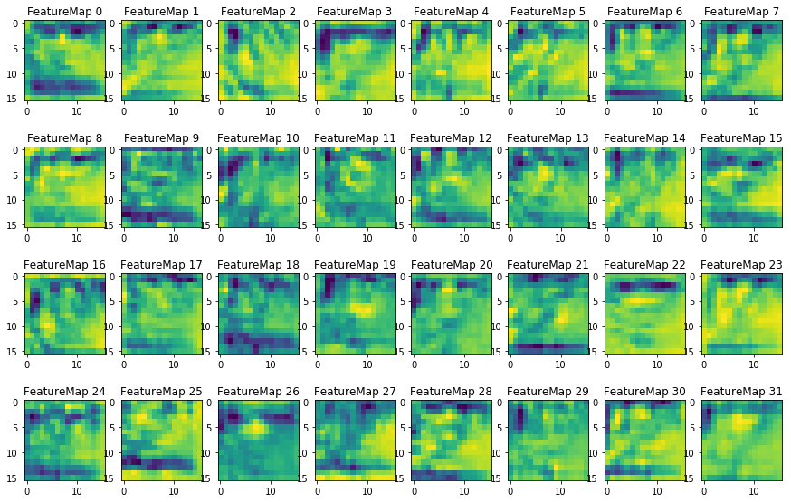

```python
l_names = ['add_0:0', 'add_1:0', 'add_2:0']

with tf.Session() as sess:
    saver.restore(sess, 'Model/3conv-2fc 3-16-32-64-1024-84-43')
    layer = sess.graph.get_tensor_by_name(l_names[1])
    outputFeatureMap(image_input=[additional_images[0]], tf_activation=layer)
```